# HW5

Fan Hong, Dantong Huang, Xin Liu, and Hao Wang (in alphabetical order)

Feb 28, 2017

## Load Hockey Data

```r
# Read data #
hd <- read.csv('http://rob-mcculloch.org/data/pens.csv')
names(hd)
```

```
## [1] "oppcall"  "timespan" "laghome"  "goaldiff" "inrow2"
```

```r
# Split data #
set.seed(99)
n <-nrow(hd)
n1=floor(n/2)
n2=n-n1
ii = sample(1:n,n)
hdtrain=hd[ii[1:n1],]
hdtest = hd[ii[n1+1:n2],]
AIC = list()
BIC = list()
```

## Comparison of logistic fit with the previous methods

```r
# Logit #
lg = glm(as.factor(oppcall)~.,data=hdtrain,family=binomial)
lg.fitprob = predict(lg,hdtest,type="response")

### ROC Curve ###
library(pROC)
rocCurve = roc(response = hdtest$oppcall, predictor=lg.fitprob)
cat("auc, logit: ", auc(rocCurve),"\n")
```

```
## auc, logit:  0.5875463
```

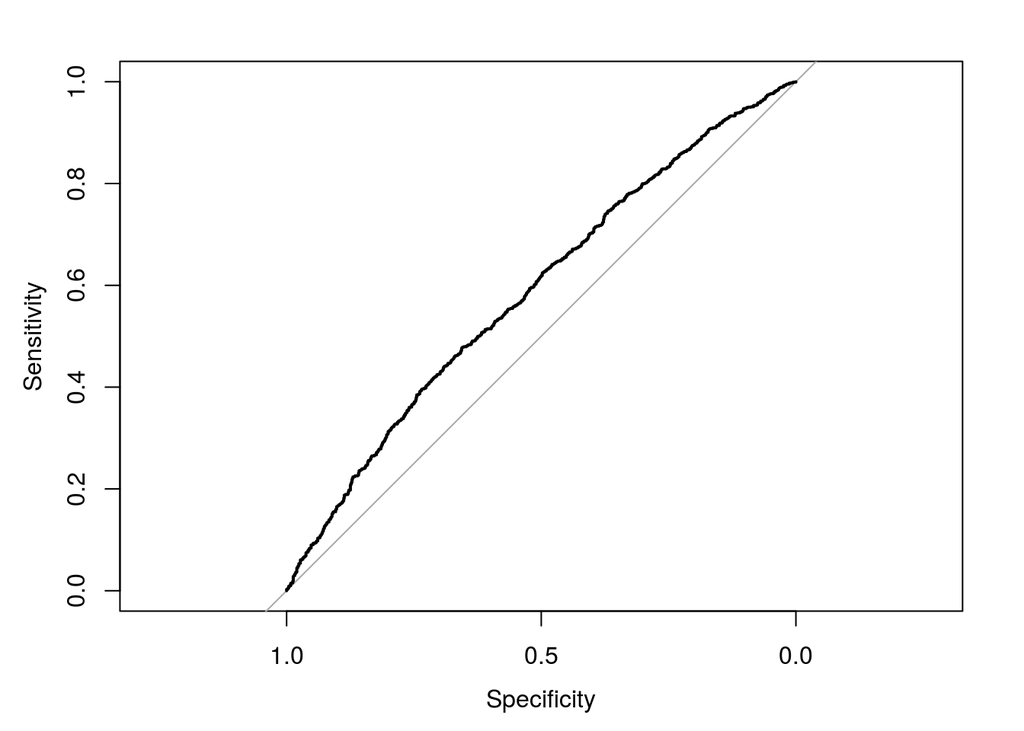

```r
plot(rocCurve)
```

## Comparison of AIC and BIC with and without goaldiff

```r
### logit without goaldiff###
lg.nogd = glm(as.factor(oppcall)~timespan+laghome+inrow2,data=hdtrain,family=binomial)

AIC$withoutgd = AIC(lg.nogd)
BIC$withoutgd = BIC(lg.nogd)
cat("AIC and BIC without goaldiff are: ",AIC$withoutgd, BIC$withoutgd,"\n")
```

```
## AIC and BIC without goaldiff are:  3361.748 3385.044
```

```r
AIC$withgd = AIC(lg)
BIC$withgd = BIC(lg)
cat("AIC and BIC with goaldiff are: ",AIC$withgd, BIC$withgd,"\n")
```

```
## AIC and BIC with goaldiff are:  3340.842 3369.962
```

AIC and BIC with goaldiff is smaller than that without goaldiff, it means goaldiff is an important feature for logistic regression.

## Load Satisfaction Data

```r
# Read data #
sd <- read.csv('http://rob-mcculloch.org/data/satisfaction.csv')
names(sd)
```

```
## [1] "yr"     "yrb"    "yr3"    "gender" "age"
```

```r
sdtrain = sd # use all samples to fit
AIC = list()
BIC = list()
```

## Logistic regression with gender and age

```r
# Logit #
lg <- glm(as.factor(yrb)~gender+age, data = sdtrain, family = binomial)
AIC$ga = AIC(lg)
BIC$ga = BIC(lg)
cat("AIC and BIC with gender and age are: ", AIC$ga, BIC$ga)
```

```
## AIC and BIC with gender and age are:  1079.485 1093.531
```

## Logistic regression with gender

```r
lg <- glm(as.factor(yrb)~gender, data = sdtrain, family = binomial)
AIC$g = AIC(lg)
BIC$g = BIC(lg)
cat("AIC and BIC with gender are: ", AIC$g, BIC$g)
```

```
## AIC and BIC with gender are:  1083.107 1092.471
```

## Logistic regression with age

```r
lg <- glm(as.factor(yrb)~age, data = sdtrain, family = binomial)
AIC$a = AIC(lg)
BIC$a = BIC(lg)
cat("AIC and BIC with gender are: ", AIC$a, BIC$a)
```

```
## AIC and BIC with gender are:  1078.281 1087.646
```

In terms of AIC, logistic regression with age is the best. In terms of BIC, logistic regression with age is also the best.

## Multinomial regression with gender and age

```r
### multinomial regression ###
library(nnet)
mlg <- multinom(as.factor(yr3)~gender+age, data = sdtrain)
AIC$ga = AIC(mlg)
BIC$ga = BIC(mlg)
cat("AIC and BIC with gender and age are: ", AIC$ga, BIC$ga)
```

```
## AIC and BIC with gender and age are:  1636.502 1664.594
```

## Multinomial regression with gender

```r
mlg <- multinom(as.factor(yr3)~gender, data = sdtrain)
AIC$g = AIC(mlg)
BIC$g = BIC(mlg)
cat("AIC and BIC with gender and age are: ", AIC$g, BIC$g)
```

```
## AIC and BIC with gender and age are:  1638.142 1656.87
```

## Multinomial regression with age

```r
## Logistic regression with gender and age
mlg <- multinom(as.factor(yr3)~age, data = sdtrain)
AIC$a = AIC(mlg)
BIC$a = BIC(mlg)
cat("AIC and BIC with gender and age are: ", AIC$a, BIC$a)
```

```
## AIC and BIC with gender and age are:  1633.34 1652.068
```

## Comparison of AIC and BIC

In terms of AIC, multinomial regression with age is the best. In terms of BIC, multinomial regression with age is also the best. These results are consistent with logistic regression above.

## Coefficients (age) Interpretation

```r
print(summary(mlg))
```

```
## Call:
## multinom(formula = as.factor(yr3) ~ age, data = sdtrain)
##
## Coefficients:
##      (Intercept)       age
## good  -1.2447764 0.6839702
## ok    -0.2367987 0.6367426
##
## Std. Errors:
##      (Intercept)       age
## good   0.2062619 0.3871845
## ok     0.1504541 0.2890451
##
## Residual Deviance: 1625.34
## AIC: 1633.34
```

From the summary information of multinomial regression with age, we have
$$\begin{align*}
\log \frac{P(\text{yr3=good})}{P(\text{yr3=bad})} = -1.244 + 0.684 \cdot \text{age}\\
\log \frac{P(\text{yr3=ok})}{P(\text{yr3=bad})} = -0.238 + 0.637 \cdot \text{age}
\end{align*}$$

From equations above, we know age has positive correlation with log-likelihood ratio of good v.s. bad and ok v.s. bad. Specifically, one unit increasing in age will result in 0.684 increasing in log-likelihood ratio of good v.s. bad and one unit increasing in age will result in 0.637 increasing in likehood of ok v.s. bad. In conclusion, an older person is more likely to like his town.